# NYC Citi Bikes

# 1. Documentation

#### **1.1. Domain knowledge**

Lauched in May of 2013 and available 24 hours/day, 7 days/week, 365 days/year, the Citi Bike is New York City’s bike share system and the largest in the nation having thousands of bikes, hundreds of stations and in 2018 registed 143,000 members.

With different type of users that could be a “Customer” has purchased either a 24-hour or 3-day pass, and a “Subscriber” has purchased an annual subscription, the bikes can be unlocked from one station and returned to any other station in the system. People use the Citi Bike services to commute to work or school, run errands, get to appointments or social engagements, and more.

#### **1.2. Business requirements**

1. Understand the business model of the company;
2. Investigated variables of interest in dataset;
3. Make relevant questions for the business model that our dataset can answer. Questions that can help the company to know where they are but for where they should go too;
4. Make visualizations to help to analyze the results obtained, take conclusions and think how those results could be usefull for the company.

#### **1.3. Business processes and data flow**

[figure not shown]

#### **1.4. Data visualisation as a tool for decision-making**

The main measure that guides the NYC Citi Bikes business is the number of users that the company has. The amount of users (subscribers or simple users) will dictate the revenues of the company, for that it is important to know about the tendencies and preferences of users to offer the best service and experience.

This report has as propose answer 3 main questions:

- **When is the peak use of NYC Citi Bikes services?**

  To know the seasons/months with more demand can help the company to how could manage/adjust their resources like the number of bikes available, or the number of people working in certain positions.
- **Who is the typical user of NYC Citi Bikes services?**

  To Knows the profile of clients it is relevant to adjust the services to fidelize the actual clients, but at the same time looking to bring new type of costumers. This could be involve advertisements more efficient, or has additional services like insurances to the people fell more secure.
- **Which travel is most common between stations?**

  Maintenance of the bikes should have special attention because accidents that happen for a lack of maintenance could bring bad reputation for the company and extra expenses with insurances or medical assistance. For that reason know which travel happen most it is important to have more resources (maintenance points, information etc) in the stations with more demand.

#### **1.5. Data types**

The different types of variables (from a total of 12 variables) that there are in this dataset are:

- factor : has character values.
- datetime: has date and time as values.
- numeric: has number as values (integer or decimals).

A more detailed information could be visible below:

```
## Rows: 4,268
## Columns: 12
## Key: bike_id [10]
## $ bike_id       <fct> 26301, 26301, 26301, 26301, 26301, 26301, 26301, 26301, …
## $ start_time    <dttm> 2018-02-26 19:11:03, 2018-02-27 07:52:49, 2018-02-27 12…
## $ stop_time     <dttm> 2018-02-26 19:15:40, 2018-02-27 07:58:13, 2018-02-27 12…
## $ start_station <fct> 3186, 3203, 3202, 3638, 3638, 3187, 3638, 3639, 3202, 36…
## $ start_lat     <dbl> 40.71959, 40.72760, 40.72722, 40.72429, 40.72429, 40.721…
## $ start_long    <dbl> -74.04312, -74.04425, -74.03376, -74.03548, -74.03548, -…
## $ end_station   <fct> 3203, 3202, 3638, 3638, 3187, 3638, 3639, 3202, 3638, 32…
## $ end_lat       <dbl> 40.72760, 40.72722, 40.72429, 40.72429, 40.72112, 40.724…
## $ end_long      <dbl> -74.04425, -74.03376, -74.03548, -74.03548, -74.03805, -…
## $ type          <fct> Subscriber, Subscriber, Subscriber, Subscriber, Subscrib…
## $ birth_year    <dbl> 1986, 1979, 1963, 1984, 1980, 1980, 1989, 1962, 1992, 19…
## $ gender        <fct> Male, Male, Male, Male, Male, Male, Male, Male, Male, Ma…
```

#### **1.6. Data quality and data bias**

The source of this dataset is open source, being known and trustworthy.

There is a significant difference between male and female users, as well as a difference between the number of subscribers and customers. Since it is a sample, to what extent the algorithm that generates the sample may be a case of gender bias, or simply the service is mostly used by men. Not forgetting that this is a sample limited to 10 bicycles, and therefore it may be limiting the dispersion of the sample data.

The dataset, according the article 4 of GDPR (General Data Protection Regulation), do not have data that could be considered like personal data that allow to identify a specific person. About sensible data, tehe dataset there are not data that are on these group of data, once the gender information by it self does not give information about person’s sex life and a person’s sexual orientation.

# 2. Data cleaning

In general the data is clean. Not all variables were used to answer the questions proposed.

Were created 3 new columns, 2 of them from the variable *start_time*, there were:

- *month*, has the month that the bike was hired (January to December);
- *week_day*, has the week day that the bike was hired (Monday to Sunday); and
- *station_travel*, join the variables *start_station* and *end_station* to this way have in just one variable which station the hires started and which station the hires stopped.

The variable gender was used and just were considered observations with values “Male” and “Female”, “Unknown” values were not considered by do not give relevant information.

The variable *birth_age* has a value of 1887 that is a unexpected value. For this reason if in the further studies the variable *birth_age* was managed, this value should not be considered.

None NA value was deleted because it could delete useful observations. The NA values were managed (not considered) specifically when the interest variables were studied and used to make visualizations.

# 3. Data visualisation

First, I investigated variables of interest with simple single-variable distribution plots. Then I plotted variables of interest to the business against each other to see if any patterns were present in the data. After selecting key visualizations I ensured these were clearly portraying the message I wanted to convey, were aesthetically pleasing, as well as accurate and not misleading. All visualizations were made in RStudio using the `ggplot` package.

### **Number of bikes per month**

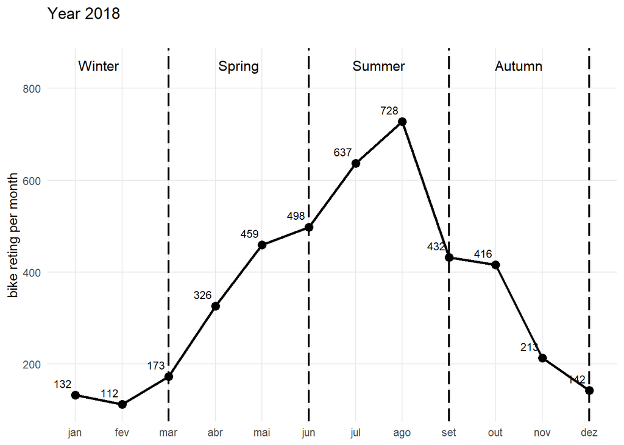

This line graph shows the tend of total users per each month of the year of 2018. The months that have more demand are the warmer months, it means during the spring and the summer, the weather conditions could influence the number of users of bikes.

The relation between the number of users per each month (or seasons) could helps to know the trend of users for eventually make less or more bikes available depending on the time of year, if there are less demand should have less bikes available in streets to the bikes don’t get damaged.

### **Bikes hired per week day during a year by Type of customer**

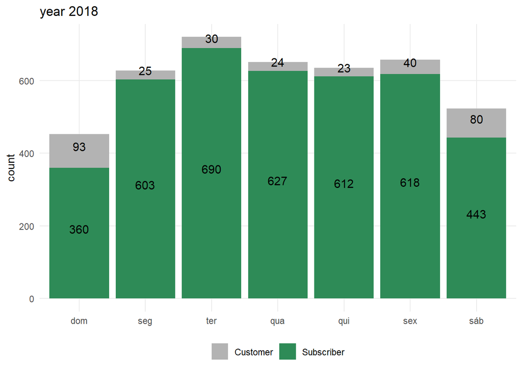

This column bar graph shows the number of users (per type of user) during 2018 per week day. It is possible take some conclusions like:

- in general the most users are subscribers;
- during the workdays (Monday to Friday) the number of subscribe users are higher than the weekend; and
- during the weekend it is when the number of costumer users is higher.

This type of information could help to identify that the most users of the services are people that use bikes to commute to work. Beyond that, know who are the most user of the services could be relevant to offer services that satisfy that people offering for example insurances that make people fells more secure to continue using the bikes.

### **Distribution by gender per month**

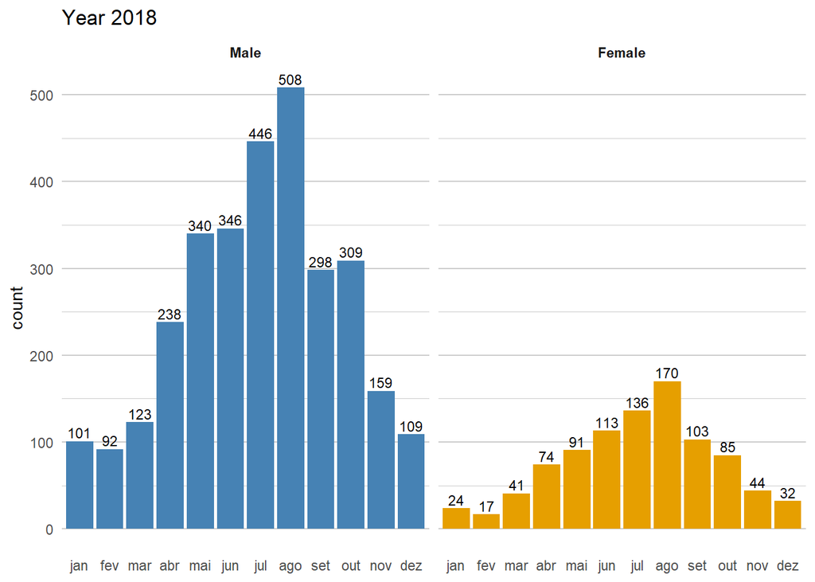

This column bar graph shows the number of users per gender per each month of 2018. It is visible that more men use bikes than women, and that information help to know where more efforts could be done to increase the number of users (different marketing, advertisements for different gender) and hence increase the revenues of the company.

### **Travel that happened most per month between stations**

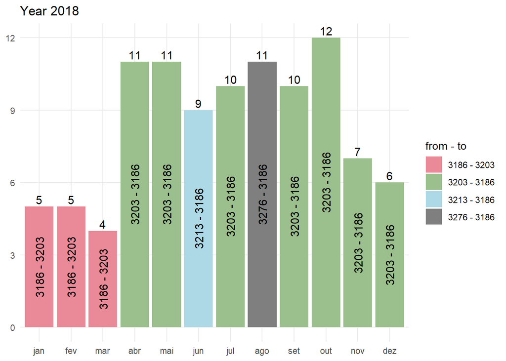

This column bar graph shows which travel(start station to end station) per month happened most during the year of 2018. It is possible to see that the travel that happened most (7 months in 12) was from the 3203 station to 3186 station. From a total of four travels that happen most per month in 2018, the station 3186 is the final station in 3 of those 4 travels.

This insight could be relevant for the business to strengthen the bicycle maintenance team close to the locals with higher utilization. It may be equally important for areas with fewer travels to do more marketing to try to bring more users.

### **Location of start stations**

[interactive chart not shown]

This leaflet graph show how spread are the stations across the city used as start station. This visualization could help to know if there are regions with more concentration, and this way have more attention and reinforce/increase the services, or in the locations with less demand make efforts to try to bring more users.